# S9T1

```python
import numpy as np
import pandas as pd
from pandas import read_csv
from sklearn.model_selection import train_test_split
import matplotlib as plt
```

## Exercici 1

Parte el conjunto de datos DelayedFlights.csv train y test. Estudia ambos conjuntos por separado, a nivel descriptivo.

a) Extracción de datos y análisis de las variables.

En este paso vamos a extraer los datos en un DF, analizar por encima los datos, filtrar datos, así como eliminar variables.

Los datos se pueden extraer de aquí

https://www.kaggle.com/datasets/giovamata/airlinedelaycauses

```python
df = pd.read_csv("DelayedFlights.csv") # este es el conjunto de datos proporcionado en el ejercicio
df.head()
```

|  | Unnamed: 0 | Year | Month | DayofMonth | DayOfWeek | DepTime | CRSDepTime | ArrTime | CRSArrTime | UniqueCarrier | ... | TaxiIn | TaxiOut | Cancelled | CancellationCode | Diverted | CarrierDelay | WeatherDelay | NASDelay | SecurityDelay | LateAircraftDelay |
| --- | --- | --- | --- | --- | --- | --- | --- | --- | --- | --- | --- | --- | --- | --- | --- | --- | --- | --- | --- | --- | --- |
| 0 | 0 | 2008 | 1 | 3 | 4 | 2003.0 | 1955 | 2211.0 | 2225 | WN | ... | 4.0 | 8.0 | 0 | N | 0 | NaN | NaN | NaN | NaN | NaN |
| 1 | 1 | 2008 | 1 | 3 | 4 | 754.0 | 735 | 1002.0 | 1000 | WN | ... | 5.0 | 10.0 | 0 | N | 0 | NaN | NaN | NaN | NaN | NaN |
| 2 | 2 | 2008 | 1 | 3 | 4 | 628.0 | 620 | 804.0 | 750 | WN | ... | 3.0 | 17.0 | 0 | N | 0 | NaN | NaN | NaN | NaN | NaN |
| 3 | 4 | 2008 | 1 | 3 | 4 | 1829.0 | 1755 | 1959.0 | 1925 | WN | ... | 3.0 | 10.0 | 0 | N | 0 | 2.0 | 0.0 | 0.0 | 0.0 | 32.0 |
| 4 | 5 | 2008 | 1 | 3 | 4 | 1940.0 | 1915 | 2121.0 | 2110 | WN | ... | 4.0 | 10.0 | 0 | N | 0 | NaN | NaN | NaN | NaN | NaN |

5 rows × 30 columns

La Oficina de Estadísticas de Transporte (BTS) del Departamento de Transporte de EE. UU. (DOT) realiza un seguimiento de la puntualidad de los **vuelos nacionales** operados por grandes compañías aéreas. La información resumida sobre la cantidad de vuelos a tiempo, retrasados, cancelados y desviados aparece en el Informe mensual de consumidores de viajes aéreos del DOT, publicado aproximadamente 30 días después de fin de mes, así como en las tablas resumidas publicadas en este sitio web

```python
df.columns # vamos a averiguar que columnas hay
```

```
Index(['Unnamed: 0', 'Year', 'Month', 'DayofMonth', 'DayOfWeek', 'DepTime',
       'CRSDepTime', 'ArrTime', 'CRSArrTime', 'UniqueCarrier', 'FlightNum',
       'TailNum', 'ActualElapsedTime', 'CRSElapsedTime', 'AirTime', 'ArrDelay',
       'DepDelay', 'Origin', 'Dest', 'Distance', 'TaxiIn', 'TaxiOut',
       'Cancelled', 'CancellationCode', 'Diverted', 'CarrierDelay',
       'WeatherDelay', 'NASDelay', 'SecurityDelay', 'LateAircraftDelay'],
      dtype='object')
```

```python
# analizamos las dimensiones

df.shape
```

```
(1936758, 30)
```

```python
# analizamos un poco las variables relacionadas con el tiempo ( min, segundos)
df2 = df [['DepTime',
       'CRSDepTime', 'ArrTime', 'CRSArrTime', 'ActualElapsedTime', 'CRSElapsedTime', 'AirTime', 'ArrDelay',
       'DepDelay', 'CarrierDelay',
       'WeatherDelay', 'NASDelay', 'SecurityDelay', 'LateAircraftDelay']]
df2
```

|  | DepTime | CRSDepTime | ArrTime | CRSArrTime | ActualElapsedTime | CRSElapsedTime | AirTime | ArrDelay | DepDelay | CarrierDelay | WeatherDelay | NASDelay | SecurityDelay | LateAircraftDelay |
| --- | --- | --- | --- | --- | --- | --- | --- | --- | --- | --- | --- | --- | --- | --- |
| 0 | 2003.0 | 1955 | 2211.0 | 2225 | 128.0 | 150.0 | 116.0 | -14.0 | 8.0 | NaN | NaN | NaN | NaN | NaN |
| 1 | 754.0 | 735 | 1002.0 | 1000 | 128.0 | 145.0 | 113.0 | 2.0 | 19.0 | NaN | NaN | NaN | NaN | NaN |
| 2 | 628.0 | 620 | 804.0 | 750 | 96.0 | 90.0 | 76.0 | 14.0 | 8.0 | NaN | NaN | NaN | NaN | NaN |
| 3 | 1829.0 | 1755 | 1959.0 | 1925 | 90.0 | 90.0 | 77.0 | 34.0 | 34.0 | 2.0 | 0.0 | 0.0 | 0.0 | 32.0 |
| 4 | 1940.0 | 1915 | 2121.0 | 2110 | 101.0 | 115.0 | 87.0 | 11.0 | 25.0 | NaN | NaN | NaN | NaN | NaN |
| ... | ... | ... | ... | ... | ... | ... | ... | ... | ... | ... | ... | ... | ... | ... |
| 1936753 | 1250.0 | 1220 | 1617.0 | 1552 | 147.0 | 152.0 | 120.0 | 25.0 | 30.0 | 3.0 | 0.0 | 0.0 | 0.0 | 22.0 |
| 1936754 | 657.0 | 600 | 904.0 | 749 | 127.0 | 109.0 | 78.0 | 75.0 | 57.0 | 0.0 | 57.0 | 18.0 | 0.0 | 0.0 |
| 1936755 | 1007.0 | 847 | 1149.0 | 1010 | 162.0 | 143.0 | 122.0 | 99.0 | 80.0 | 1.0 | 0.0 | 19.0 | 0.0 | 79.0 |
| 1936756 | 1251.0 | 1240 | 1446.0 | 1437 | 115.0 | 117.0 | 89.0 | 9.0 | 11.0 | NaN | NaN | NaN | NaN | NaN |
| 1936757 | 1110.0 | 1103 | 1413.0 | 1418 | 123.0 | 135.0 | 104.0 | -5.0 | 7.0 | NaN | NaN | NaN | NaN | NaN |

1936758 rows × 14 columns

```python
# las columnas CarrierDelay,WeatherDelay,NASDelay,SecurityDelay,LateAircraftDelay son la justificación del retraso,
# con muchos NaN, y que la suma de las cinco es el retraso.
dfjustificacion = df [["CarrierDelay","WeatherDelay","NASDelay","SecurityDelay","LateAircraftDelay"]]
dfjustificacion.isnull().value_counts()
```

```
CarrierDelay  WeatherDelay  NASDelay  SecurityDelay  LateAircraftDelay
False         False         False     False          False                1247488
True          True          True      True           True                  689270
dtype: int64
```

```python
# un tercio de valores son nulos, así que vamos a ignorar estas variables para cualquier estudio posterior.
```

Podemos ver que DepDelay y ArrDelay **recogen la diferencia entre el tiempo esperado y el tiempo real** de llegada o salida, así como **elapsed time** nos da información del tiempo transcurrido, por lo que las primeras cuatro columnas nos informan de los mismo que las cinco siguientes.

```python
dfcate = df[["UniqueCarrier", 'FlightNum',
       'TailNum',]]
dfcate
```

|  | UniqueCarrier | FlightNum | TailNum |
| --- | --- | --- | --- |
| 0 | WN | 335 | N712SW |
| 1 | WN | 3231 | N772SW |
| 2 | WN | 448 | N428WN |
| 3 | WN | 3920 | N464WN |
| 4 | WN | 378 | N726SW |
| ... | ... | ... | ... |
| 1936753 | DL | 1621 | N938DL |
| 1936754 | DL | 1631 | N3743H |
| 1936755 | DL | 1631 | N909DA |
| 1936756 | DL | 1639 | N646DL |
| 1936757 | DL | 1641 | N908DL |

1936758 rows × 3 columns

```python
# podemos ver que Flight y Tail no aprtan mucha infromación
```

```python
# montamos un DF con las siguientes variables

df3 = df[[  'Month', "DayOfWeek",  'UniqueCarrier', 'ActualElapsedTime', 'CRSElapsedTime', 'AirTime', 'ArrDelay',
       'DepDelay', 'Origin', 'Dest', 'Distance',
       'Cancelled',  'Diverted']]
df3
```

|  | Month | DayOfWeek | UniqueCarrier | ActualElapsedTime | CRSElapsedTime | AirTime | ArrDelay | DepDelay | Origin | Dest | Distance | Cancelled | Diverted |
| --- | --- | --- | --- | --- | --- | --- | --- | --- | --- | --- | --- | --- | --- |
| 0 | 1 | 4 | WN | 128.0 | 150.0 | 116.0 | -14.0 | 8.0 | IAD | TPA | 810 | 0 | 0 |
| 1 | 1 | 4 | WN | 128.0 | 145.0 | 113.0 | 2.0 | 19.0 | IAD | TPA | 810 | 0 | 0 |
| 2 | 1 | 4 | WN | 96.0 | 90.0 | 76.0 | 14.0 | 8.0 | IND | BWI | 515 | 0 | 0 |
| 3 | 1 | 4 | WN | 90.0 | 90.0 | 77.0 | 34.0 | 34.0 | IND | BWI | 515 | 0 | 0 |
| 4 | 1 | 4 | WN | 101.0 | 115.0 | 87.0 | 11.0 | 25.0 | IND | JAX | 688 | 0 | 0 |
| ... | ... | ... | ... | ... | ... | ... | ... | ... | ... | ... | ... | ... | ... |
| 1936753 | 12 | 6 | DL | 147.0 | 152.0 | 120.0 | 25.0 | 30.0 | MSP | ATL | 906 | 0 | 0 |
| 1936754 | 12 | 6 | DL | 127.0 | 109.0 | 78.0 | 75.0 | 57.0 | RIC | ATL | 481 | 0 | 0 |
| 1936755 | 12 | 6 | DL | 162.0 | 143.0 | 122.0 | 99.0 | 80.0 | ATL | IAH | 689 | 0 | 0 |
| 1936756 | 12 | 6 | DL | 115.0 | 117.0 | 89.0 | 9.0 | 11.0 | IAD | ATL | 533 | 0 | 0 |
| 1936757 | 12 | 6 | DL | 123.0 | 135.0 | 104.0 | -5.0 | 7.0 | SAT | ATL | 874 | 0 | 0 |

1936758 rows × 13 columns

**Analizamos la cantidad de valores perdidos.**

```python
variables= [  'Month',  "DayOfWeek",  'UniqueCarrier', 'ActualElapsedTime', 'CRSElapsedTime', 'AirTime', 'ArrDelay',
       'DepDelay', 'Origin', 'Dest', 'Distance',
       'Cancelled',  'Diverted']
for i in variables :
    print (df3[i].isnull().value_counts())# miramos la cantidad de nulos
```

```
False    1936758
Name: Month, dtype: int64
False    1936758
Name: DayOfWeek, dtype: int64
False    1936758
Name: UniqueCarrier, dtype: int64
False    1928371
True        8387
Name: ActualElapsedTime, dtype: int64
False    1936560
True         198
Name: CRSElapsedTime, dtype: int64
False    1928371
True        8387
Name: AirTime, dtype: int64
False    1928371
True        8387
Name: ArrDelay, dtype: int64
False    1936758
Name: DepDelay, dtype: int64
False    1936758
Name: Origin, dtype: int64
False    1936758
Name: Dest, dtype: int64
False    1936758
Name: Distance, dtype: int64
False    1936758
Name: Cancelled, dtype: int64
False    1936758
Name: Diverted, dtype: int64
```

```python
df4= df3.dropna()
df4.isnull().value_counts()
#eliminamos los valores perdidos
```

```
Month  DayOfWeek  UniqueCarrier  ActualElapsedTime  CRSElapsedTime  AirTime  ArrDelay  DepDelay  Origin  Dest   Distance  Cancelled  Diverted
False  False      False          False              False           False    False     False     False   False  False     False      False       1928371
dtype: int64
```

```python
# hemos eliminado datos, pero antes de seguir, vamos a ver si estos datos son en los casos que han sido Cancelados o derivados.
df3["Diverted"].value_counts()
# vemos que hay 7754 valores derivados
```

```
0    1929004
1       7754
Name: Diverted, dtype: int64
```

```python
df3["Cancelled"].value_counts()# vemos que hay 633 vuelos cancelados
```

```
0    1936125
1        633
Name: Cancelled, dtype: int64
```

```python
df4.shape[0]-df3.shape[0]# esta es la diferencia de valores tars eliminar los perdidos
```

```
-8387
```

```python
# vamos a observar aquellos valores en que el vuelo ha sido desviado
indic=  ["ActualElapsedTime",  "CRSElapsedTime","AirTime"  ,"ArrDelay"]
for j in indic:
    valores= df3[[j,"Diverted"]][df3[ "Diverted"]== 1].value_counts()
    print (valores)
# observamos que los valores nan están relacionados con una cancelación o desvío
```

```
Series([], dtype: int64)
CRSElapsedTime  Diverted
85.0            1           141
80.0            1           138
60.0            1           136
65.0            1           132
170.0           1           117
                           ...
417.0           1             1
435.0           1             1
441.0           1             1
443.0           1             1
635.0           1             1
Length: 448, dtype: int64
Series([], dtype: int64)
Series([], dtype: int64)
```

```python
# si observamos lo siguiente
df3["Cancelled"].value_counts()[1]+df3["Diverted"].value_counts()[1] - df3["AirTime"].isnull().value_counts()[1]
```

```
0
```

```python
# Es decir, los vuelos cancelados y derivados coinciden con el números de datos perdidos en las variables de
#"ActualElapsedTime","AirTime"  ,"ArrDelay"
# pero no coinciden con los 198 NaN de CRSElapsedTime, así que habrá que eliminar los 198 valores nulos de CRSElapsedTime

df5 = df3.dropna( subset=["CRSElapsedTime"])
df5.shape
```

```
(1936560, 13)
```

```python
# vamos a separa el conjunto de entrenamiento y el de testeo, sin tener en cuenta si hay variables de salida.

from sklearn.model_selection import train_test_split
```

b) **Separación en Train y Test, y estudio sobre la similutud o diferencia de las muestras**

Vamos a separar el conjunto en Train y test. Luego lo separaremos en continuas y categóricas y las analizaremos.

Vamos a comparar las medias con un test de hipótesis, para ver si siguen distribuciones parecidas.

```python
X_train, X_test= train_test_split(df5, test_size=0.20, random_state=42, shuffle=True )
```

- Miramos las estadísticas de ambos conjuntos

```python
X_train.describe()
```

|  | Month | DayOfWeek | ActualElapsedTime | CRSElapsedTime | AirTime | ArrDelay | DepDelay | Distance | Cancelled | Diverted |
| --- | --- | --- | --- | --- | --- | --- | --- | --- | --- | --- |
| count | 1.549248e+06 | 1.549248e+06 | 1.542663e+06 | 1.549248e+06 | 1.542663e+06 | 1.542663e+06 | 1.549248e+06 | 1.549248e+06 | 1.549248e+06 | 1.549248e+06 |
| mean | 6.111698e+00 | 3.984851e+00 | 1.333527e+02 | 1.343408e+02 | 1.083152e+02 | 4.224887e+01 | 4.322104e+01 | 7.660559e+02 | 3.130551e-04 | 3.937394e-03 |
| std | 3.482857e+00 | 1.996166e+00 | 7.211235e+01 | 7.139421e+01 | 6.869566e+01 | 5.686159e+01 | 5.347392e+01 | 5.750371e+02 | 1.769060e-02 | 6.262502e-02 |
| min | 1.000000e+00 | 1.000000e+00 | 1.400000e+01 | -2.100000e+01 | 0.000000e+00 | -7.000000e+01 | 6.000000e+00 | 1.100000e+01 | 0.000000e+00 | 0.000000e+00 |
| 25% | 3.000000e+00 | 2.000000e+00 | 8.000000e+01 | 8.200000e+01 | 5.800000e+01 | 9.000000e+00 | 1.200000e+01 | 3.380000e+02 | 0.000000e+00 | 0.000000e+00 |
| 50% | 6.000000e+00 | 4.000000e+00 | 1.160000e+02 | 1.160000e+02 | 9.000000e+01 | 2.400000e+01 | 2.400000e+01 | 6.060000e+02 | 0.000000e+00 | 0.000000e+00 |
| 75% | 9.000000e+00 | 6.000000e+00 | 1.650000e+02 | 1.650000e+02 | 1.370000e+02 | 5.600000e+01 | 5.300000e+01 | 9.980000e+02 | 0.000000e+00 | 0.000000e+00 |
| max | 1.200000e+01 | 7.000000e+00 | 1.114000e+03 | 6.600000e+02 | 1.091000e+03 | 2.461000e+03 | 2.467000e+03 | 4.962000e+03 | 1.000000e+00 | 1.000000e+00 |

```python
X_test.describe()
```

|  | Month | DayOfWeek | ActualElapsedTime | CRSElapsedTime | AirTime | ArrDelay | DepDelay | Distance | Cancelled | Diverted |
| --- | --- | --- | --- | --- | --- | --- | --- | --- | --- | --- |
| count | 387312.000000 | 387312.000000 | 385708.000000 | 387312.000000 | 385708.000000 | 385708.000000 | 387312.000000 | 387312.000000 | 387312.000000 | 387312.000000 |
| mean | 6.109782 | 3.984865 | 133.118413 | 134.150336 | 108.124763 | 42.003946 | 43.039999 | 764.301204 | 0.000382 | 0.003759 |
| std | 3.481432 | 1.995169 | 71.850386 | 71.129836 | 68.429917 | 56.475842 | 53.120903 | 572.339866 | 0.019544 | 0.061197 |
| min | 1.000000 | 1.000000 | 16.000000 | -25.000000 | 0.000000 | -109.000000 | 6.000000 | 11.000000 | 0.000000 | 0.000000 |
| 25% | 3.000000 | 2.000000 | 80.000000 | 82.000000 | 58.000000 | 9.000000 | 12.000000 | 338.000000 | 0.000000 | 0.000000 |
| 50% | 6.000000 | 4.000000 | 116.000000 | 116.000000 | 90.000000 | 24.000000 | 24.000000 | 606.000000 | 0.000000 | 0.000000 |
| 75% | 9.000000 | 6.000000 | 165.000000 | 165.000000 | 137.000000 | 55.000000 | 53.000000 | 998.000000 | 0.000000 | 0.000000 |
| max | 12.000000 | 7.000000 | 750.000000 | 660.000000 | 733.000000 | 1951.000000 | 1952.000000 | 4962.000000 | 1.000000 | 1.000000 |

Podemos observar que las variables continuas "ActualElapsedTime", "CRSElapsedTime","AirTime" ,"ArrDelay", "DepDelay" y distance se parecen ambos conjuntos, tanto en media como desviación

- Análisis de la parte continua: procedemos a analizar ambos conjuntos

```python
indice=  ["ActualElapsedTime",  "CRSElapsedTime","AirTime"  ,"ArrDelay", "DepDelay", "Distance"] # las variables continuas.
# vamos a observar su comportamiento en ambos conjuntos
```

```python
# hacemos un muestreo simple de n = 30.000
sample_train  = X_train[indice].sample(30000)
sample_test  = X_test[indice].sample(30000)
```

```python
import matplotlib.pyplot as plt
import seaborn as sns
```

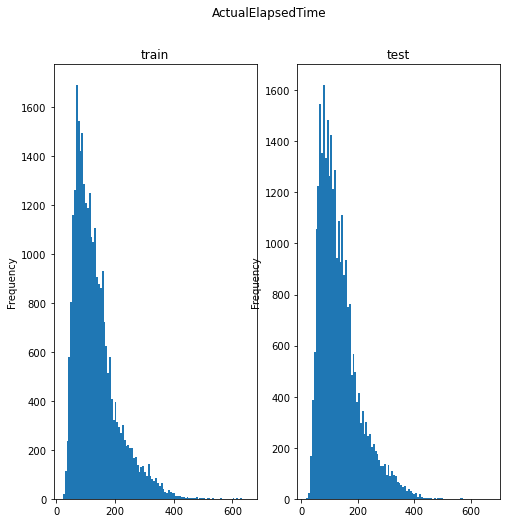

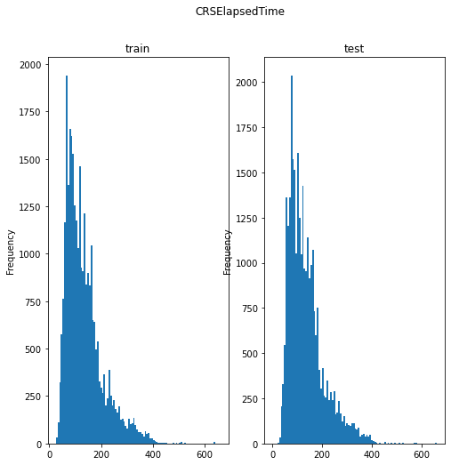

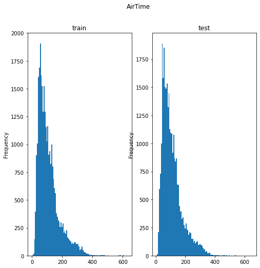

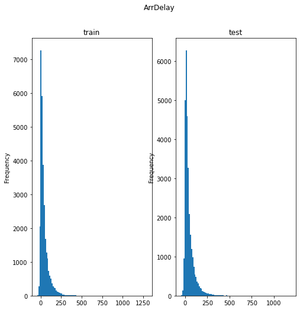

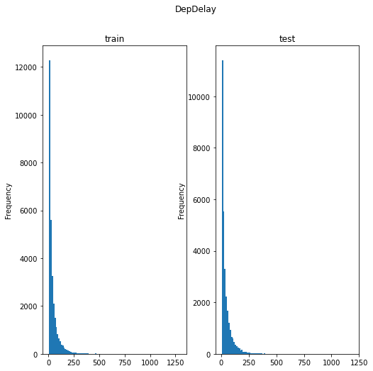

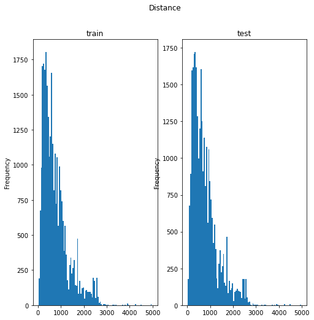

```python
for i in indice :
    plt.subplot(1,2,1)
    sample_train[i].plot ( kind= "hist", figsize= (8,8), bins =100)
    plt.title( "train")
    plt.subplot(1,2,2)
    sample_test[i].plot ( kind= "hist", figsize= (8,8), bins =100)
    plt.title(  "test")
    plt.suptitle(i)
    plt.show()
```

```python
# podemos observar que los datos tienden a un valor -ax^2 +bx+c  o logarítimica , o e^-x para x>0 ( aproximacion muy burda ),
# vamos a normalizar la función para poder comparar ambos conjuntos en un test de hipótesis


# En el ejercicio 2 piden hacer transformación, y en el ejercicio 3 analizarlas, por motivos de argumentación y de análisis,
#lo hiré haciendo sobre la marcha y no de la manera que pide el ejercicio

# ahora hago transformación de yeo-Johnson para poder hacer un test de hipótesis
pt = preprocessing.PowerTransformer(method='yeo-johnson', standardize=False)

sample_train2  = X_train[indice].sample(40000)
sample_test2  = X_test[indice].sample(40000)
XtrainPT=pt.fit_transform(sample_train2)
XtestPT = pt.fit_transform(sample_test2)
df_train_scaled3= pd.DataFrame(XtrainPT, columns= indice )
df_test_scaled3= pd.DataFrame(XtestPT, columns= indice )

#vamos a eliminar los valores NaN


df_train_scaled3= df_train_scaled3.dropna()
df_test_scaled3= df_test_scaled3.dropna()
```

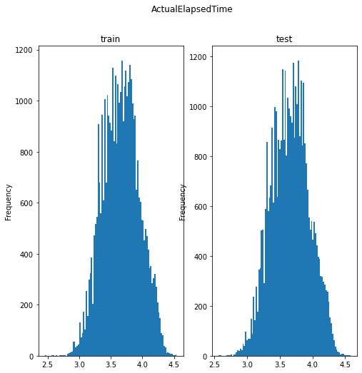

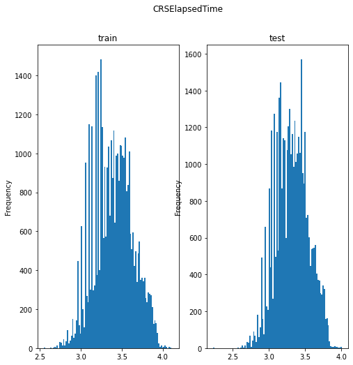

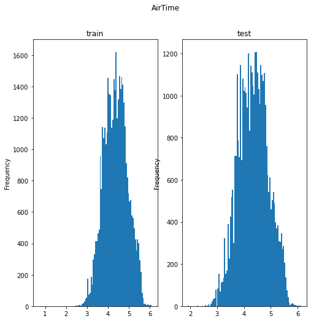

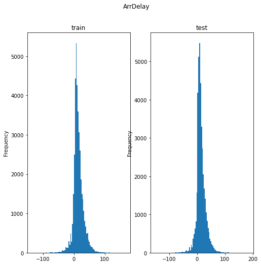

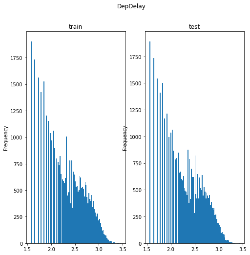

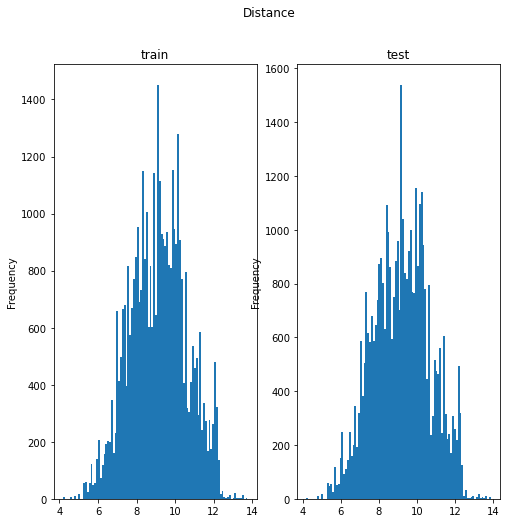

```python
for i in indice :
    plt.subplot(1,2,1)
    df_train_scaled3[i].plot ( kind= "hist", figsize= (8,8), bins =100)

    plt.title( "train")
    plt.subplot(1,2,2)
    df_test_scaled3[i].plot ( kind= "hist", figsize= (8,8), bins =100)

    plt.title(  "test")
    plt.suptitle(i)
    plt.show()
```

```python
# podemos ver que se comportan de manera muy parecida tanto el test como el train.Muy similares a normales a
# excepción de depdelay,
df_train_scaled3. describe()
```

|  | ActualElapsedTime | CRSElapsedTime | AirTime | ArrDelay | DepDelay | Distance |
| --- | --- | --- | --- | --- | --- | --- |
| count | 39823.000000 | 39823.000000 | 39823.000000 | 39823.000000 | 39823.000000 | 39823.000000 |
| mean | 3.657643 | 3.393676 | 4.367354 | 14.153794 | 2.278636 | 9.128006 |
| std | 0.287953 | 0.234703 | 0.559519 | 16.092284 | 0.416351 | 1.467999 |
| min | 2.456808 | 2.547391 | 0.689686 | -135.426400 | 1.567517 | 4.180515 |
| 25% | 3.444974 | 3.214897 | 3.959679 | 5.563983 | 1.935594 | 8.029666 |
| 50% | 3.661520 | 3.392386 | 4.366919 | 11.995441 | 2.271311 | 9.142770 |
| 75% | 3.855797 | 3.557969 | 4.755852 | 21.485226 | 2.606865 | 10.132968 |
| max | 4.541073 | 4.118141 | 6.093170 | 166.356545 | 3.463680 | 13.751510 |

```python
df_test_scaled3.describe()
```

|  | ActualElapsedTime | CRSElapsedTime | AirTime | ArrDelay | DepDelay | Distance |
| --- | --- | --- | --- | --- | --- | --- |
| count | 39850.000000 | 39850.000000 | 39850.000000 | 39850.000000 | 39850.000000 | 39850.000000 |
| mean | 3.659775 | 3.313406 | 4.347490 | 14.178727 | 2.257514 | 9.192620 |
| std | 0.289602 | 0.223293 | 0.556310 | 16.250520 | 0.407305 | 1.492216 |
| min | 2.566743 | 2.230684 | 1.914806 | -149.241153 | 1.559082 | 4.195021 |
| 25% | 3.446051 | 3.149555 | 3.942552 | 5.571594 | 1.922229 | 8.083863 |
| 50% | 3.662751 | 3.312037 | 4.346050 | 11.665114 | 2.252188 | 9.204365 |
| 75% | 3.860525 | 3.468494 | 4.731060 | 21.543403 | 2.580588 | 10.234279 |
| max | 4.582826 | 4.006221 | 6.135264 | 185.637454 | 3.438689 | 13.878668 |

- Observamos que en ambos conjuntos la media como la desviación estándar de las seis variables difiere menos de un 5% en ambas muestras
- Vamos a comparar las dos conjunto, la parte continua, aplicando un test de hipótesis, asumiendo que para cada variable continua la media de ambos grupos coinciden,H0, siendo H1 que ambas medias no coincide, usando el test de hipótesis Z, y Student

```python
from scipy import stats
from statsmodels.stats import weightstats as stests
# Example of the Student's t-test
from scipy.stats import ttest_ind
indice=  ["ActualElapsedTime",  "CRSElapsedTime","AirTime"  ,"ArrDelay", "DepDelay", "Distance"]

for ini in indice:
    stat, pval = ttest_ind(df_test_scaled3[ini],df_train_scaled3[ini])

    print ("valor de t-stat de ", ini ,"es   : ",stat)
    if pval <= 0.05:
        print(" la hipótesis no es válida para la variable: ", ini," el valor de p es :", pval,  )
    else:
        print ( "hipótesis valida para ", ini,  " el valor de p es :", pval)
```

```
valor de t-stat de  ActualElapsedTime es   :  1.0419334002767153
hipótesis valida para  ActualElapsedTime  el valor de p es : 0.29744571914969636
valor de t-stat de  CRSElapsedTime es   :  -49.455456083991585
 la hipótesis no es válida para la variable:  CRSElapsedTime  el valor de p es : 0.0
valor de t-stat de  AirTime es   :  -5.024943584976157
 la hipótesis no es válida para la variable:  AirTime  el valor de p es : 5.046675705774584e-07
valor de t-stat de  ArrDelay es   :  0.21759143593036415
hipótesis valida para  ArrDelay  el valor de p es : 0.827748014985844
valor de t-stat de  DepDelay es   :  -7.237950562633564
 la hipótesis no es válida para la variable:  DepDelay  el valor de p es : 4.596032809045309e-13
valor de t-stat de  Distance es   :  6.160924367566365
 la hipótesis no es válida para la variable:  Distance  el valor de p es : 7.266623780615091e-10
```

```python
for ini2 in indice:
    ztest, pz = stests.ztest(x1=df_test_scaled3[ini2],x2=df_train_scaled3[ini2])
    print ("valor de ztest de ", ini2 ,"es   : ",ztest)
    if pz <= 0.05:
        print(" la hipótesis no es válida para la variable: ", ini2," el valor de p es :", pz,  )
    else:
        print ( "hipótesis valida para ", ini2,  " el valor de p es :", pz)
```

```
valor de ztest de  ActualElapsedTime es   :  1.0419334002767153
hipótesis valida para  ActualElapsedTime  el valor de p es : 0.2974425574973584
valor de ztest de  CRSElapsedTime es   :  -49.455456083991585
 la hipótesis no es válida para la variable:  CRSElapsedTime  el valor de p es : 0.0
valor de ztest de  AirTime es   :  -5.024943584976157
 la hipótesis no es válida para la variable:  AirTime  el valor de p es : 5.035805469887305e-07
valor de ztest de  ArrDelay es   :  0.21759143593036417
hipótesis valida para  ArrDelay  el valor de p es : 0.8277474577615708
valor de ztest de  DepDelay es   :  -7.237950562633564
 la hipótesis no es válida para la variable:  DepDelay  el valor de p es : 4.555154096046796e-13
valor de ztest de  Distance es   :  6.1609243675663645
 la hipótesis no es válida para la variable:  Distance  el valor de p es : 7.232152906223385e-10
```

```python
for ini2 in indice:
    ktest, pk = stats.ks_2samp(df_test_scaled3[ini2],df_train_scaled3[ini2])
    print ("valor de ktest de ", ini2 ,"es   : ",ktest)
    if pk <= 0.05:
        print(" la hipótesis no es válida para la variable: ", ini2," el valor de p es :", pk,  )
    else:
        print ( "hipótesis valida para ", ini2,  " el valor de p es :", pk)
```

```
valor de ktest de  ActualElapsedTime es   :  0.01179179097115779
 la hipótesis no es válida para la variable:  ActualElapsedTime  el valor de p es : 0.007798113359633092
valor de ktest de  CRSElapsedTime es   :  0.15044300452337223
 la hipótesis no es válida para la variable:  CRSElapsedTime  el valor de p es : 0.0
valor de ktest de  AirTime es   :  0.02027971956585431
 la hipótesis no es válida para la variable:  AirTime  el valor de p es : 1.511606908344295e-07
valor de ktest de  ArrDelay es   :  0.021383227431320873
 la hipótesis no es válida para la variable:  ArrDelay  el valor de p es : 2.4186598267798623e-08
valor de ktest de  DepDelay es   :  0.047478042659974906
 la hipótesis no es válida para la variable:  DepDelay  el valor de p es : 1.8614579534895148e-39
valor de ktest de  Distance es   :  0.030678168083228763
 la hipótesis no es válida para la variable:  Distance  el valor de p es : 1.0150852443109266e-16
```

Tras probar con varios test de hipotesis, no podemos asegurar que tengan la misma media, a pesar de su parecido más que razonable. el nivel de confianza debería ser muy bajo, del orden de 10 a la menos 60. Así que vamos a tener que tratar las dos estadísticas como diferentes.

Por ejemplo en el test Z, el valor de p es

$$ p = 2( 1 - \phi ( \frac{\sqrt[]{n}*\left| \mu - \bar{x}\right|}{\sigma })$$

Tras hacer probaturas con distintas n.... podemos ver que, menos para ArrDelay, las variables continuas cumplen lo siguiente

$$\sigma\approx 10^{-1}$$$$\left|\mu -\bar{x} \right| \approx 10^{-2}$$$$ \sqrt[]{n} \approx 10^{2}$$$$\phi( 10^2 - 10^3)$$

donde $$\phi(t)$$

es la función de distrubión canónica, que para valores de t superiores a 3,5 la función de distribución canónica toma valores 0,9999.. por lo que el orden de magnitud debería estar cerca de t= 1

Si hiciésemos valores de n muy pequeños, del orden de menos de mil, las disparidad de la muestra impediría aproximar a una normal. La diferencia de medias sería mucho más grande así como la desviación,haciendo que el test volviese a requerie de un valor p muy bajo

c) Descripción estádística

Vamos a analizar la correlación de las 6 variables continuas.

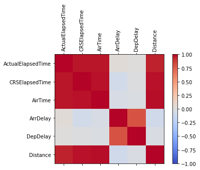

```python
# para el train
corr = df_train_scaled3.corr()
fig = plt.figure()
ax = fig.add_subplot(111)
cax = ax.matshow(corr,cmap='coolwarm', vmin=-1, vmax=1)
fig.colorbar(cax )
ticks = np.arange(0,len(df_train_scaled3.columns),1)
ax.set_xticks(ticks)
plt.xticks(rotation=90)
ax.set_yticks(ticks)
ax.set_xticklabels(df_train_scaled3.columns)
ax.set_yticklabels( df_train_scaled3.columns)
plt.show()
```

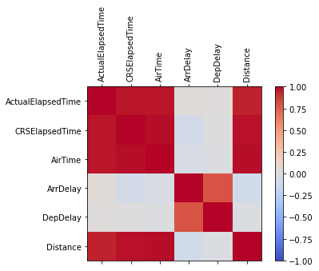

```python
# para el test
corr = df_test_scaled3.corr()
fig = plt.figure()
ax = fig.add_subplot(111)
cax = ax.matshow(corr,cmap='coolwarm', vmin=-1, vmax=1)
fig.colorbar(cax )
ticks = np.arange(0,len(df_test_scaled3.columns),1)
ax.set_xticks(ticks)
plt.xticks(rotation=90)
ax.set_yticks(ticks)
ax.set_xticklabels(df_test_scaled3.columns)
ax.set_yticklabels( df_test_scaled3.columns)
plt.show()
```

Actual Elapsed time= tiempo real transcurrido

crs= tiempo estimado transcurrido

air tiempo= tiempo de vuelo

arrdelay =retraso de llegada del vuelo

depdelay= retraso la salida del vuelo

distance= distancia

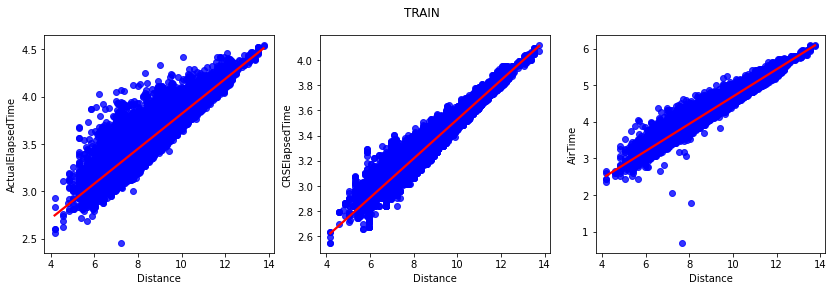

```python
#obviamente podemos observar una fuerte dependencia entre las la distancia de vuelo, y el tiempo de vuelo así como del tiempo
# total entre la salida y la llegada....mientras que la distancia apenas influye en el retraso de llegada, y menos aún de salida
# del vuelo

# vamos a mirar  la dependencia de manera gráfica, tanto para el train como para test
indice2=  ["ActualElapsedTime",  "CRSElapsedTime","AirTime" , "Distance"]

f_distance_train= df_train_scaled3[indice2]

f_distance_test= df_test_scaled3[indice2]

import seaborn as sns

f,axs= plt.subplots(1, 3, figsize=(14,4))
plt.suptitle("TRAIN")

sns.regplot(data=f_distance_train, x=  "Distance",y = "ActualElapsedTime",ax= axs[0], ci=None,scatter_kws={"color": "blue"}, line_kws={"color": "red"})

sns.regplot( data=f_distance_train, x=  "Distance",y = "CRSElapsedTime",ax= axs[1], ci=None,scatter_kws={"color": "blue"}, line_kws={"color": "red"})

sns.regplot( data=f_distance_train, x=  "Distance",y = "AirTime",ax= axs[2]  , ci=None, scatter_kws={"color": "blue"}, line_kws={"color": "red"})
```

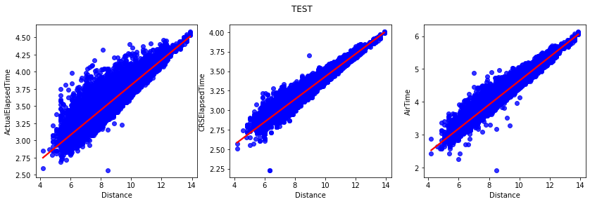

```python
f,axs= plt.subplots(1, 3, figsize=(14,4))
plt.suptitle("TEST")

sns.regplot(data=f_distance_test, x=  "Distance",y = "ActualElapsedTime",ax= axs[0], ci=None,scatter_kws={"color": "blue"}, line_kws={"color": "red"})

sns.regplot( data=f_distance_test, x=  "Distance",y = "CRSElapsedTime",ax= axs[1], ci=None,scatter_kws={"color": "blue"}, line_kws={"color": "red"})

sns.regplot( data=f_distance_test, x=  "Distance",y = "AirTime",ax= axs[2]  , ci=None, scatter_kws={"color": "blue"}, line_kws={"color": "red"})
```

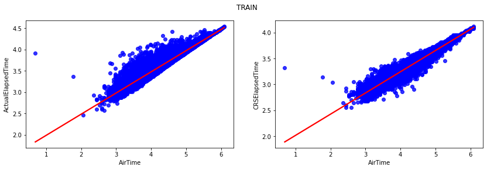

```python
# y ahora miramos la dependencia de Air time con ElapsedTime y Crselapsed.
f,axs= plt.subplots(1, 2, figsize=(14,4))
plt.suptitle("TRAIN")

sns.regplot(data=f_distance_train, x=  "AirTime",y = "ActualElapsedTime",ax= axs[0], ci=None,scatter_kws={"color": "blue"}, line_kws={"color": "red"})

sns.regplot( data=f_distance_train, x=  "AirTime",y = "CRSElapsedTime",ax= axs[1], ci=None,scatter_kws={"color": "blue"}, line_kws={"color": "red"})
```

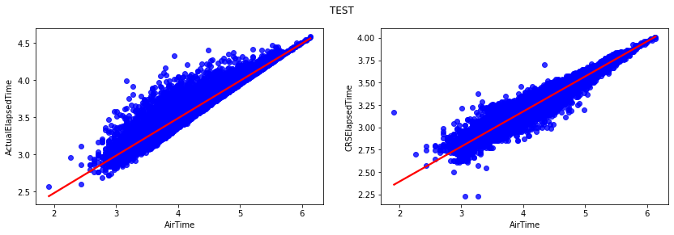

```python
# y ahora miramos la dependencia de Air time con ElapsedTime y Crselapsed.
f,axs= plt.subplots(1, 2, figsize=(14,4))
plt.suptitle("TEST")

sns.regplot(data=f_distance_test, x=  "AirTime",y = "ActualElapsedTime",ax= axs[0], ci=None,scatter_kws={"color": "blue"}, line_kws={"color": "red"})

sns.regplot( data=f_distance_test, x=  "AirTime",y = "CRSElapsedTime",ax= axs[1], ci=None,scatter_kws={"color": "blue"}, line_kws={"color": "red"})
```

```python
#Miramos la correlación entre las cuatro variables tanto del train como del test
corr11 = df_train_scaled3[indice2].corr()
corr12 = df_test_scaled3[indice2].corr()
print (corr11)
print(corr12)
```

```
                   ActualElapsedTime  CRSElapsedTime   AirTime  Distance
ActualElapsedTime           1.000000        0.962046  0.965017  0.938453
CRSElapsedTime              0.962046        1.000000  0.976374  0.973420
AirTime                     0.965017        0.976374  1.000000  0.977735
Distance                    0.938453        0.973420  0.977735  1.000000
                   ActualElapsedTime  CRSElapsedTime   AirTime  Distance
ActualElapsedTime           1.000000        0.962064  0.965564  0.937915
CRSElapsedTime              0.962064        1.000000  0.976573  0.972837
AirTime                     0.965564        0.976573  1.000000  0.977924
Distance                    0.937915        0.972837  0.977924  1.000000
```

[output not shown]

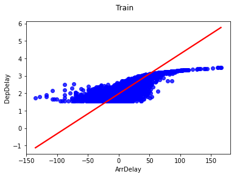

```python
# y por otro lado Arrdelay y DepDelay también tienen una correlación alejada de cero

corr21 = df_train_scaled3[["ArrDelay"  , "DepDelay"]].corr()

print(corr21)

plt.suptitle("Train")
sns.regplot(data= df_train_scaled3, x="ArrDelay"  ,y = "DepDelay", robust= True, ci=None,scatter_kws={"color": "blue"}, line_kws={"color": "red"})
```

```
          ArrDelay  DepDelay
ArrDelay  1.000000  0.791379
DepDelay  0.791379  1.000000
```

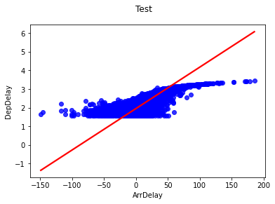

```python
corr22 = df_test_scaled3[["ArrDelay"  , "DepDelay"]].corr()

print(corr22)

plt.suptitle("Test")
sns.regplot(data= df_test_scaled3, x="ArrDelay"  ,y = "DepDelay", robust= True, ci=None,scatter_kws={"color": "blue"}, line_kws={"color": "red"})
```

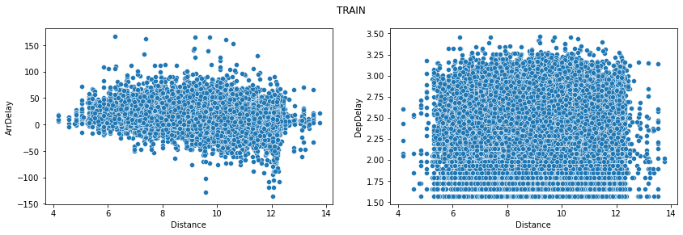

```python
# podemos ver las variable "ActualElapsedTime",  "CRSElapsedTime","AirTime" , "Distance" están correlacionadas alrededor
# de un 95% y podemos tratarlas independientemente de ArrDelay y DepDelay, no tienen relación lineal. Mientras que
# estas dos últimas tienen una correlación de casi el 80%.

# ahora sólo queda por ver que relación hay entre una de las variables, pongamos, Distancia, y ArrDelay y DepDelay. Como, el
# el coeficiente de correlación no llega ni a 0,8, no voy a tratarlas como dependientes linealmente.


f,axs= plt.subplots(1, 2, figsize=(14,4))
plt.suptitle("TRAIN")


sns.scatterplot(data= df_train_scaled3, x="Distance"  ,y = "ArrDelay", ax= axs[0])

sns.scatterplot(data= df_train_scaled3, x="Distance"  ,y = "DepDelay", ax= axs[1])
```

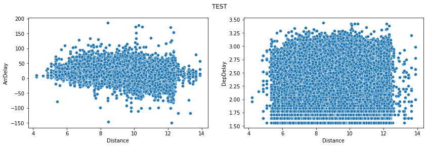

```python
f,axs= plt.subplots(1, 2, figsize=(14,4))
plt.suptitle("TEST")


sns.scatterplot(data= df_test_scaled3, x="Distance"  ,y = "ArrDelay", ax= axs[0])

sns.scatterplot(data= df_test_scaled3, x="Distance"  ,y = "DepDelay", ax= axs[1])
```

- Lo esperado. La distancia del vuelo no afecta en nada al retaso de la salida del vuelo, mientras que la hora de llega si se ve afectada por la distancia de manera mínima, por lo que podemos concluirlas independientes. Para analizar las variables categóricas vamos a considerar sólo estas tres variables, ya que las distancia está correlacionada un 95% con ActualElapsedTime, CRSElapsedTime,AirTime
- **Análisis de categóricas.**

```python
# Volvemos a  las variables "X_train" y "X_test" para analizar las categóricas, contando que en estas deficiniciones
# de variables, los valores NaN no habían sido eliminados

X_train
```

|  | Month | DayOfWeek | UniqueCarrier | ActualElapsedTime | CRSElapsedTime | AirTime | ArrDelay | DepDelay | Origin | Dest | Distance | Cancelled | Diverted |
| --- | --- | --- | --- | --- | --- | --- | --- | --- | --- | --- | --- | --- | --- |
| 798783 | 5 | 6 | US | 101.0 | 120.0 | 89.0 | 105.0 | 124.0 | CLT | FLL | 631 | 0 | 0 |
| 916554 | 6 | 6 | WN | 79.0 | 95.0 | 65.0 | 108.0 | 124.0 | LAS | ABQ | 487 | 0 | 0 |
| 405458 | 3 | 4 | WN | 52.0 | 60.0 | 42.0 | 12.0 | 20.0 | HOU | MSY | 303 | 0 | 0 |
| 168521 | 1 | 2 | B6 | 227.0 | 190.0 | 191.0 | 43.0 | 6.0 | SWF | FLL | 1119 | 0 | 0 |
| 100209 | 1 | 4 | DL | 115.0 | 78.0 | 75.0 | 47.0 | 10.0 | JAX | ATL | 270 | 0 | 0 |
| ... | ... | ... | ... | ... | ... | ... | ... | ... | ... | ... | ... | ... | ... |
| 259213 | 2 | 4 | UA | 128.0 | 137.0 | 99.0 | 3.0 | 12.0 | ORD | BOS | 867 | 0 | 0 |
| 1414604 | 8 | 7 | CO | 252.0 | 241.0 | 226.0 | 25.0 | 14.0 | IAH | SFO | 1635 | 0 | 0 |
| 131932 | 1 | 6 | NW | 282.0 | 297.0 | 257.0 | 51.0 | 66.0 | DTW | LAX | 1979 | 0 | 0 |
| 671255 | 4 | 4 | MQ | 44.0 | 55.0 | 29.0 | -2.0 | 9.0 | DFW | TXK | 181 | 0 | 0 |
| 121958 | 1 | 7 | MQ | 108.0 | 115.0 | 88.0 | 20.0 | 27.0 | ORD | BWI | 622 | 0 | 0 |

1549248 rows × 13 columns

```python
X_test
```

|  | Month | DayOfWeek | UniqueCarrier | ActualElapsedTime | CRSElapsedTime | AirTime | ArrDelay | DepDelay | Origin | Dest | Distance | Cancelled | Diverted |
| --- | --- | --- | --- | --- | --- | --- | --- | --- | --- | --- | --- | --- | --- |
| 1151949 | 7 | 5 | UA | 79.0 | 70.0 | 62.0 | 100.0 | 91.0 | DEN | ABQ | 349 | 0 | 0 |
| 1872338 | 12 | 1 | MQ | 84.0 | 75.0 | 43.0 | 20.0 | 11.0 | FNT | ORD | 223 | 0 | 0 |
| 1860921 | 12 | 7 | FL | 88.0 | 70.0 | 56.0 | 34.0 | 16.0 | ATL | PNS | 272 | 0 | 0 |
| 1465256 | 9 | 7 | UA | 336.0 | 347.0 | 317.0 | 648.0 | 659.0 | IAD | SFO | 2419 | 0 | 0 |
| 1722740 | 11 | 6 | B6 | 173.0 | 108.0 | 74.0 | 141.0 | 76.0 | PIT | JFK | 340 | 0 | 0 |
| ... | ... | ... | ... | ... | ... | ... | ... | ... | ... | ... | ... | ... | ... |
| 1781780 | 12 | 1 | YV | 171.0 | 164.0 | 140.0 | 121.0 | 114.0 | SAT | CLT | 1095 | 0 | 0 |
| 824633 | 5 | 2 | MQ | 79.0 | 63.0 | 47.0 | 40.0 | 24.0 | GGG | DFW | 140 | 0 | 0 |
| 299688 | 2 | 3 | FL | 100.0 | 94.0 | 78.0 | 12.0 | 6.0 | SRQ | ATL | 445 | 0 | 0 |
| 1795022 | 12 | 2 | OO | 93.0 | 105.0 | 78.0 | 16.0 | 28.0 | SLC | PHX | 507 | 0 | 0 |
| 1479188 | 9 | 6 | DL | 129.0 | 146.0 | 106.0 | -1.0 | 16.0 | SAT | ATL | 874 | 0 | 0 |

387312 rows × 13 columns

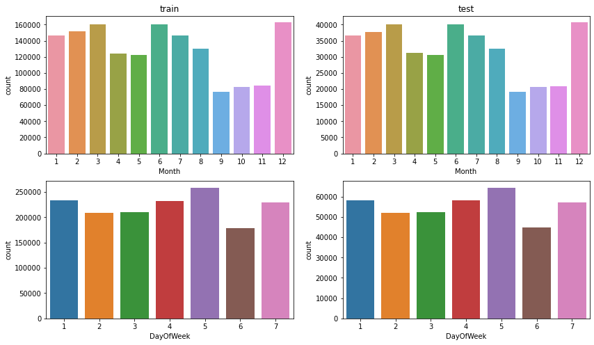

```python
# analizamos la proporcion de vuelos por meses y dias de la semana

f,axs= plt.subplots(2, 2, figsize=(14,8))


sns.countplot( data= X_train , x= "Month", ax= axs[0,0]).set(title="train")


sns.countplot( data= X_test , x= "Month", ax= axs[0,1] ).set(title="test")


sns.countplot( data= X_train , x= "DayOfWeek", ax= axs[1,0])


sns.countplot( data= X_test , x= "DayOfWeek", ax= axs[1,1] )
```

```python
# observamos que la proporción de vuelos  se mantiene en ambos grupos.
# con más salidad de vuelos al incio del fin de semana y final del fin de semana( Viernes y Domingos) o incio de semana
# en Lunes, cuando suelen iniciarse la vacaciones o salidas de negocios. Mientras que los meses con más ocupación son los
# Verano e invierno ( Hemisferio Norte). Recordemos que los vuelos son los Nacionales de Estados Unidos.
# vamos a investigar sobre los aeropuertos y su influencia


# primero vamos a analizar la cantidad e vuelos en un aeropuerto
```

```python
#observamos 303 origenes

orig_tr=X_train["Origin"].value_counts()

origin_train=  np.array(orig_tr.index.values)


orig_te=X_test["Origin"].value_counts()
origin_test=  np.array(orig_te.index.values)

dest_tr=X_train["Dest"].value_counts()
des_train=  np.array(dest_tr.index.values)

dest_te=X_test["Dest"].value_counts()
des_test=  np.array(dest_te.index.values)
```

```python
print ( origin_train.shape)
print ( origin_test.shape)
print ( des_train.shape)
print ( des_test.shape)
```

```
(303,)
(301,)
(304,)
(300,)
```

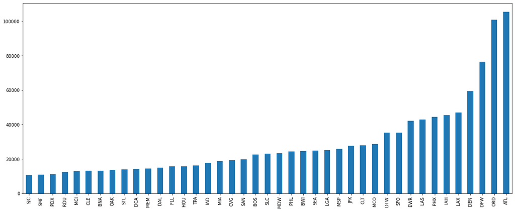

```python
orig_tr[orig_tr>10000].sort_values().plot(kind="bar",figsize= (20,8), )
```

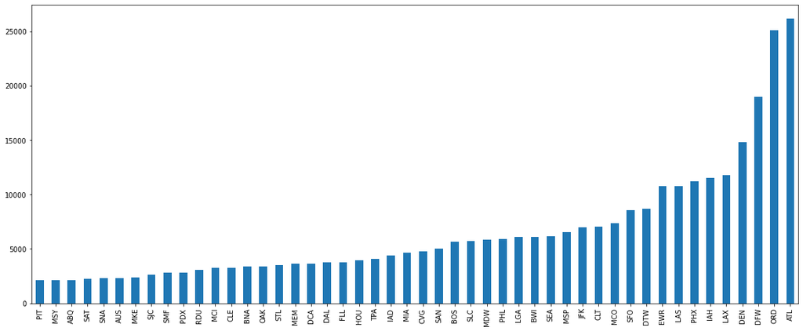

```python
orig_te[orig_te>2000].sort_values().plot(kind="bar",figsize= (20,8), )
```